# ---{Módulo 9}--- Geometria Plana -----

#### $$ \text{---\{ Proporcionalidades \}---} \\[24pt] $$

### $$ \text{Teorema de Tales} $$

$$ \text{Prof. Eduardo Ono} \\[24pt] $$

**Sumário**

- 1. Objetivos
- 1. Conceitos e Definições
  - 2.1. Definição. <sub><sup>(Feixe de Retas Paralelas)</sup></sub>
  - 2.2. Definição. <sub><sup>(Trasversal de feixe de retas paralelas)</sup></sub>
- 1. Teorema de Tales
- 1. Aplicações
  - 4.1. Conversão de escalas lineares
- 1. Referências

# 1. Objetivos

- Compreender o Teorema de Tales e sua importância para a resolução de problemas geométricos;
- Enunciar e demonstrar o Teorema de Tales utilizando o conceito de áreas;
- Aplicar os conceitos do Teorema de Tales em tópicos além da Geometria.

# 2. Conceitos e Definições

## 2.1. Definição. <sub><sup>(Feixe de Retas Paralelas)</sup></sub>

Um **feixe de retas paralelas** é um conjunto de retas coplanares paralelas entre si.

## 2.2. Definição. <sub><sup>(Trasversal de feixe de retas paralelas)</sup></sub>

Uma **transversal de feixe de retas paralelas** é uma reta do plano do feixe que concorre com todas as retas do feixe.

# 3. Teorema de Tales

Se duas retas são transversais de um feixe de retas paralelas, então a razão entre dois segmentos **quaisquer** de uma das transversais é igual à razão entre os respectivos segmentos correspondentes da outra transversal.

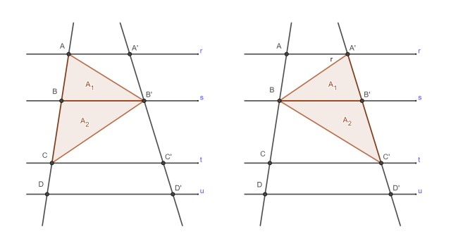

*Demonstração.*

Hipótese: $r /\negthickspace/ s /\negthickspace/ t$, $a$ e $b$ tranversais.

Tese: $\,\cfrac{AB}{BC} = \cfrac{A'B'}{B'C'}\,$ (segmentos adjacentes) e $\,\cfrac{AB}{CD} = \cfrac{A'B'}{C'D'}\,$ (segmentos não adjacentes).

Considerando o triângulo $AB'C$, a ceviana (qualquer segmento que parte de um vértice de um triângulo e corta o lado oposto a esse vértice) $\overline{BB'}$ determina os triângulos $AB'B$, de área $A_1$, e o triângulo $BB'C$, de área $A_2$. Temos, então:

$$ \cfrac{A_1}{A_2} = \cfrac{\cfrac{\overline{AB} \cdot h}{2}}{\cfrac{\overline{BC} \cdot h}{2}} = \cfrac{\ \overline{AB}\ }{\overline{BC}}\ . $$

Analogamente, para os triângulos $A'BB'$ e $B'BC'$, temos:

$$ \cfrac{A_1}{A_2} = \cfrac{\cfrac{\overline{A'B'} \cdot h}{2}}{\cfrac{\overline{B'C'} \cdot h}{2}} = \cfrac{\ \overline{A'B'}\ }{\overline{B'C'}}\ . $$

Portanto,

$$ \boxed{\ \cfrac{\ \overline{AB}\ }{\ \overline{BC}\ } = \cfrac{\ \overline{A'B'} }{\ \overline{B'C'}\ }\ } $$

Alguns autores demonstram esse Teorema para o caso de dois segmentos não contínuos em cada transversal.

Analogamente ao que foi demonstrado, podemos obter:

$$ \begin{align*} \cfrac{\ \overline{BC}\ }{\ \overline{CD}\ } &= \cfrac{\ \overline{B'C'}\ }{\ \overline{C'D'}\ } \\ \ \\ \cfrac{\ \overline{AB}\ }{\ \overline{BC}\ } \cdot \cfrac{\ \overline{BC}\ }{\ \overline{CD}\ } &= \cfrac{\ \overline{A'B'}\ }{\ \overline{B'C'}\ } \cdot \cfrac{\ \overline{B'C'}\ }{\ \overline{C'D'}\ } \\ \end{align*} $$$$ \boxed{\ \cfrac{\ \overline{AB}\ }{\ \overline{CD}\ } = \cfrac{\ \overline{A'B'}\ }{\ \overline{C'D'}\ }\ } $$

# 4. Aplicações

## 4.1. Conversão de escalas lineares

Na escala Celsius, o ponto de fusão do gelo e da ebulição da água é 0°C e 100°C, respectivamente. Na escala Farenheigt, as respectivas temperaturas são 32°F e 212°F. Sabendo-se que as duas escalas são lineares, o Teorema de Tales pode ser aplicado para a coversão das respectivas temperaturas.

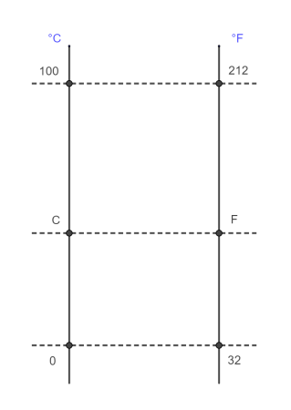

$$ \begin{align*} \cfrac{C - 0}{100 - 0} &= \cfrac{F - 32}{212 - 32} \\ \\ \cfrac{C}{100} &= \cfrac{F - 32}{180} \\ \\ \cfrac{C}{5} &= \cfrac{F - 32}{9} \\ \end{align*} $$

A partir dessa última igualdade, podemos obter $C = C(F)$ e $F = F(C)$:

$$ \boxed{C = \cfrac{5}{9}\,(F -32)} $$$$ \boxed{F = \cfrac{9}{5}\,C + 32} $$

# 5. Referências

| Thumb | Descrição |
| --- | --- |
|  | <sup>[Amo Matemática]</sup> [**Demonstração do Teorema de Tales \| Prof. Fernão**](https://www.youtube.com/watch?v=Ylt9iIqQ2Q8) <sub>(13:09, YouTube, 05/Set/2023)</sub> |